# Citibike

Tarun Bhadri, Ben Boeke, Taeyoung Justin Yun, Victor Manuel Jauregui-Tapia, Vincent Qu Dee

11/30/2021

```r
library(tidyverse)
library(gganimate)
library(geosphere)
library(lubridate)
library(ggplot2)
library(dplyr)
library(knitr)
library(leaflet)
```

## Data frame setup

### Data Cleaning

```r
#Start New RMD File for Analysis
#Reading the new csv file
citisample <- read.csv("citibike.csv")
citisample$X <- NULL
citisample$start.station.id <- as.factor(citisample$start.station.id)
citisample$end.station.id <- as.factor(citisample$end.station.id)
citisample$bikeid <- as.factor(citisample$bikeid)
citisample$usertype <- as.factor(citisample$usertype)
citisample$gender <- as.factor(citisample$gender)
# Fix gender
citisample$gender <- ifelse(citisample$gender == 1, "male", ifelse(citisample$gender == 2, "female", "unknown"))
citisample$gender <- as.factor(citisample$gender)
# Create a column for approximate age
citisample$age <- 2021 - citisample$birth.year
```

### Data Cleaning Continued

```r
citisample$starttime <- as.POSIXct(strptime(citisample$starttime, "%Y-%m-%d %H:%M:%S"))
citisample$stoptime <- as.POSIXct(strptime(citisample$stoptime, "%Y-%m-%d %H:%M:%S"))

citisample$starthour <- hour(citisample$starttime)
citisample$day <- date(citisample$starttime)

citisample$month <- as.factor(month(citisample$day))

citisample$numWeekday <- wday(citisample$starttime)
citisample$dayid <- as.factor(ifelse(citisample$numWeekday < 6, "Weekday", "Weekend"))
citisample$weekNum <- week(citisample$starttime)
citisample$distmeters <- distHaversine(cbind(citisample$start.station.latitude, citisample$start.station.longitude), cbind(citisample$end.station.latitude, citisample$end.station.longitude))

#rename weekdays
citisample$numWeekday <- ifelse(citisample$numWeekday==1,"Sunday",citisample$numWeekday)
citisample$numWeekday <- ifelse(citisample$numWeekday==2,"Monday",citisample$numWeekday)
citisample$numWeekday <- ifelse(citisample$numWeekday==3,"Tuesday",citisample$numWeekday)
citisample$numWeekday <- ifelse(citisample$numWeekday==4,"Wednesday",citisample$numWeekday)
citisample$numWeekday <- ifelse(citisample$numWeekday==5,"Thursday",citisample$numWeekday)
citisample$numWeekday <- ifelse(citisample$numWeekday==6,"Friday",citisample$numWeekday)
citisample$numWeekday <- ifelse(citisample$numWeekday==7,"Saturday",citisample$numWeekday)
citisample$numWeekday <- factor(citisample$numWeekday,levels = c("Monday","Tuesday","Wednesday","Thursday","Friday","Saturday","Sunday"))

citisample$speed <- citisample$distmeters / citisample$tripduration
str(citisample)
```

```
## 'data.frame':    205518 obs. of  24 variables:
##  $ tripduration           : int  118 1138 162 534 622 143 305 127 544 221 ...
##  $ starttime              : POSIXct, format: "2019-01-06 16:34:54" "2019-01-28 17:55:54" ...
##  $ stoptime               : POSIXct, format: "2019-01-06 16:36:52" "2019-01-28 18:14:53" ...
##  $ start.station.id       : Factor w/ 896 levels "116","119","120",..: 249 190 9 787 893 770 12 280 410 841 ...
##  $ start.station.name     : chr  "Cooper Square & Astor Pl" "South St & Gouverneur Ln" "E 2 St & Avenue C" "Pearl St & Anchorage Pl" ...
##  $ start.station.latitude : num  40.7 40.7 40.7 40.7 40.7 ...
##  $ start.station.longitude: num  -74 -74 -74 -74 -74 ...
##  $ end.station.id         : Factor w/ 900 levels "116","119","120",..: 808 789 774 777 592 626 65 118 233 54 ...
##  $ end.station.name       : chr  "St Marks Pl & 1 Ave" "E 6 St & Avenue D" "E 9 St & Avenue C" "Atlantic Ave & Furman St" ...
##  $ end.station.latitude   : num  40.7 40.7 40.7 40.7 40.7 ...
##  $ end.station.longitude  : num  -74 -74 -74 -74 -74 ...
##  $ bikeid                 : Factor w/ 19108 levels "14529","14530",..: 9437 10969 11326 8449 7262 13870 13335 14022 1534 12871 ...
##  $ usertype               : Factor w/ 2 levels "Customer","Subscriber": 2 2 2 2 2 2 2 2 2 2 ...
##  $ birth.year             : int  1992 1977 1964 1980 1983 1989 1997 1956 1970 1980 ...
##  $ gender                 : Factor w/ 3 levels "female","male",..: 2 1 2 2 2 2 2 2 2 3 ...
##  $ age                    : num  29 44 57 41 38 32 24 65 51 41 ...
##  $ starthour              : int  16 17 5 19 21 11 21 23 17 12 ...
##  $ day                    : Date, format: "2019-01-06" "2019-01-28" ...
##  $ month                  : Factor w/ 12 levels "1","2","3","4",..: 1 1 1 1 1 1 1 1 1 1 ...
##  $ numWeekday             : Factor w/ 7 levels "Monday","Tuesday",..: 7 1 3 5 6 3 2 3 4 7 ...
##  $ dayid                  : Factor w/ 2 levels "Weekday","Weekend": 1 1 1 2 2 1 1 1 1 1 ...
##  $ weekNum                : num  1 4 1 4 1 5 5 5 1 2 ...
##  $ distmeters             : num  571 3390 377 1414 2322 ...
##  $ speed                  : num  4.84 2.98 2.33 2.65 3.73 ...
```

### Merging NYC Weather Data

```r
#Merging Datasets
weather <- read.csv("NYCWeather2019.csv")
weather$STATION <- NULL
weather$NAME <- NULL
weather$DATE <- as.Date(weather$DATE, format= "%m/%d/%Y")
weather$TAVG <- (weather$TMAX + weather$TMIN)/2

citiday <- citisample %>%
  group_by(day, gender, dayid) %>%
  summarize(count = n(),
            dist = mean(distmeters, na.rm = TRUE),
            dur = mean(tripduration, na.rm = TRUE),
            speed = dist/dur)
combined_gender <- merge(citiday, weather, by.x = "day", by.y = "DATE")
```

## Citi Bike Data Context

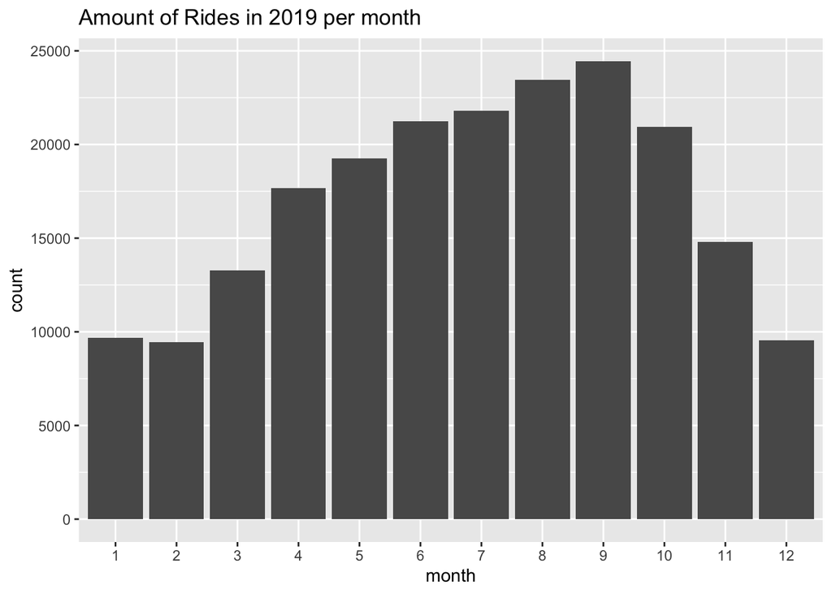

```r
ggplot(citisample, aes(x=month)) + geom_bar() +labs( title = "Amount of Rides in 2019 per month")
```

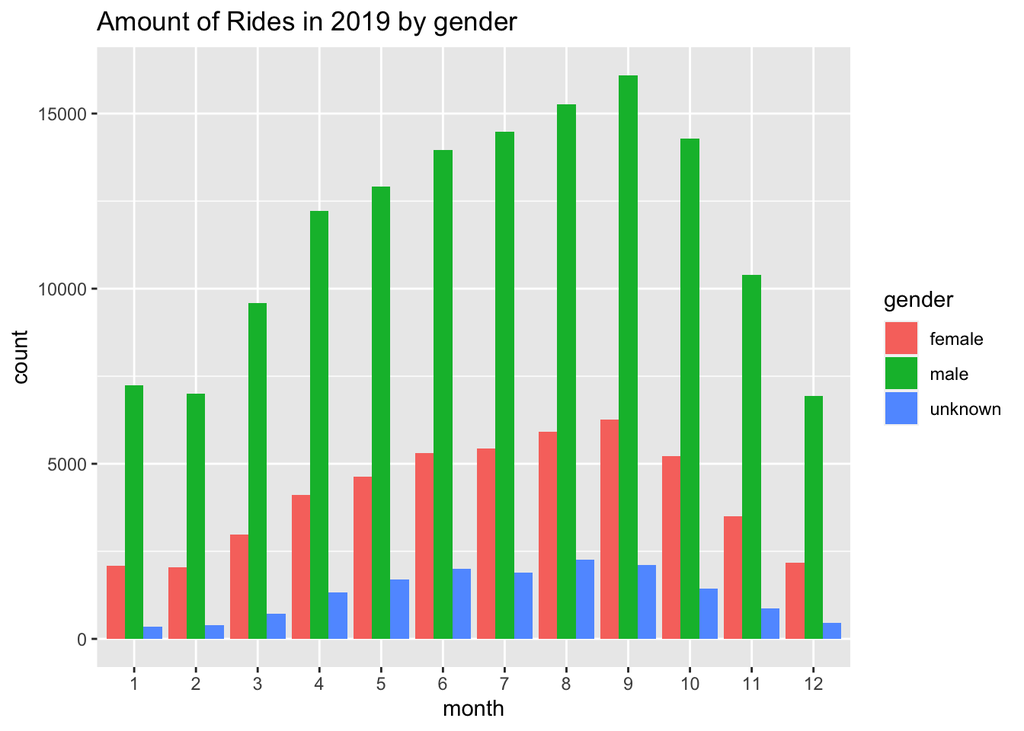

```r
ggplot(citisample, aes(x=month, fill = gender)) + geom_bar(position=position_dodge()) +labs( title = "Amount of Rides in 2019 by gender")
```

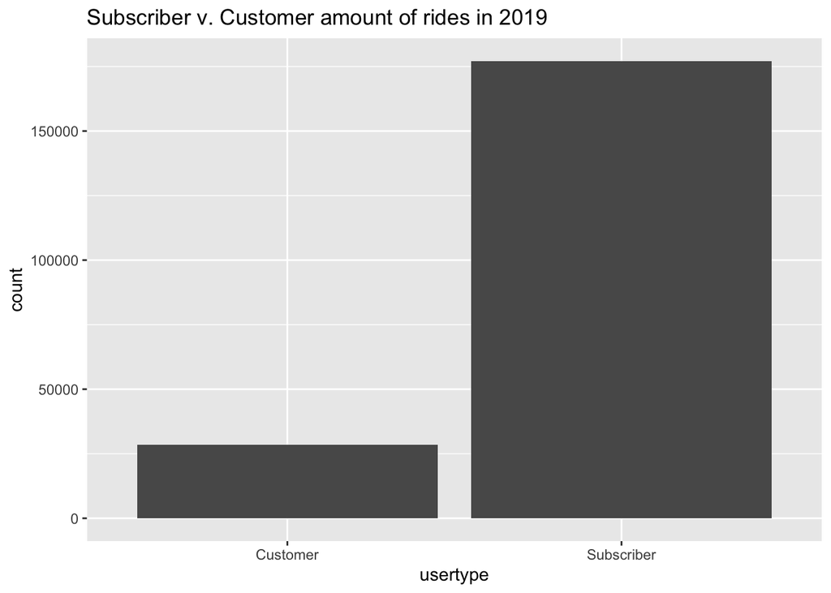

```r
ggplot(citisample, aes(x=usertype)) + geom_bar(position=position_dodge()) +labs( title = "Subscriber v. Customer amount of rides in 2019")
```

## Assymetric Traffic

```r
citisample$route <- paste(citisample$start.station.name,citisample$end.station.name,sep=" -> ")

citisample %>%
  group_by(route) %>%
  summarize(count=n()) %>%
  arrange(desc(count)) %>%
  top_n(n=5) %>% kable(format="markdown")
```

| route | count |
| --- | --- |
| E 7 St & Avenue A -> Cooper Square & Astor Pl | 89 |
| Central Park S & 6 Ave -> Central Park S & 6 Ave | 71 |
| Pier 40 - Hudson River Park -> West St & Chambers St | 61 |
| Central Park S & 6 Ave -> 5 Ave & E 88 St | 60 |
| Vesey Pl & River Terrace -> North Moore St & Greenwich St | 59 |
| West Drive & Prospect Park West -> West Drive & Prospect Park West | 59 |

This table shows the top 5 most popular routes from our sample 2019 data. Management should consider these routes when allocating bikes across stations. One should expect the ending station to have a surplus of bikes compared to the departing station. Our team will continue to analyze which stations actually have a surplus or deficit.

```r
bike_departures <- group_by(citisample, station = `start.station.name`, latitude = `start.station.latitude`, longitude = `start.station.longitude`)

departure <- summarise(bike_departures, departure_count = n())
bike_arrivals <- group_by(citisample, station = `end.station.name`, latitude = `end.station.latitude`, longitude = `end.station.longitude`)
arrival <- summarise(bike_arrivals, arrival_count = n())
#merge departure and arrival data into one df
bike_deficit <- merge(departure, arrival, all = TRUE)
# make NA's = 0
bike_deficit[is.na(bike_deficit)] <- 0

#make deficit variable: == arrivals - departures
bike_deficit$deficit <- bike_deficit$departure_count - bike_deficit$arrival_count
```

```r
#Now we are just going to show the 10% of most problematic stations. That means that we are only going to show the 10% of stations where the difference between arrivals and departures is higher
bike_deficit10percent<-sort(abs(bike_deficit$deficit),decreasing = TRUE)
minimum<-bike_deficit10percent[length(bike_deficit10percent)%/%10]

bike_deficit_worststations<-bike_deficit[abs(bike_deficit$deficit)>=minimum,]



# circle size representative of the magnitude of the deficit or surplus the station has (absolute val of how many more departures it has than arrivals)
# Red circles have a net deficit, blue circles have a net surplus
# click on station to see station name and net deficit or surplus
leaflet(bike_deficit_worststations) %>%
  addTiles() %>%
  addCircleMarkers(lng = bike_deficit_worststations$longitude, lat = bike_deficit_worststations$latitude,
                   popup = paste(bike_deficit_worststations$station, "<br>", ifelse(bike_deficit_worststations$deficit>=0, "Bike deficit = ", "Bike surplus = "),
                                abs(bike_deficit_worststations$deficit)),
                   radius = abs(bike_deficit_worststations$deficit)/5, color = ifelse(bike_deficit_worststations$deficit>0, "red", "green"))
```

[interactive chart not shown]

This map shows the top 10% problemtic stations.

```r
bike_deficit_10<-arrange(bike_deficit, (deficit))[1:10,]


def_icon <- makeIcon("/Applications/Junior/TO_404Group Project/myrepo/red_bike.png", iconWidth = 24, iconHeight =32)

leaflet(bike_deficit_10) %>%
  addTiles() %>%
  addMarkers(lng = ~longitude, lat = ~latitude, label=paste(bike_deficit_10$station,bike_deficit_10$deficit), icon = def_icon)
```

[interactive chart not shown]

```r
surp_icon <- makeIcon("/Applications/Junior/TO_404Group Project/myrepo/green_bike.png", iconWidth = 24, iconHeight =32)
bike_surplus_10<-arrange(bike_deficit, -deficit)[1:10,]


leaflet(bike_surplus_10) %>%
  addTiles() %>%
  addMarkers(lng = ~longitude, lat = ~latitude, label=paste(bike_surplus_10$station,bike_surplus_10$deficit), icon = surp_icon)
```

[interactive chart not shown]

## Bike Usage

### Top 10 Most Used Bikes

```r
topbikes <- citisample %>%
  group_by(bikeid) %>%
  summarize(count=n()) %>%
  arrange(desc(count)) %>%
  top_n(n=10) %>% kable(format="markdown")
topbikes
```

| bikeid | count |
| --- | --- |
| 35025 | 46 |
| 35077 | 42 |
| 34355 | 40 |
| 35329 | 40 |
| 34379 | 39 |
| 34937 | 39 |
| 34981 | 39 |
| 35218 | 39 |
| 35296 | 39 |
| 35298 | 39 |

### How Usertype Affects Ridership

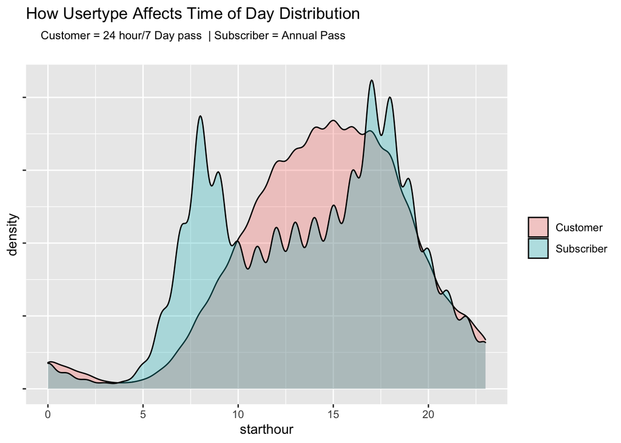

```r
#time of day by usertype
citisample %>% ggplot(aes(x=starthour,group=usertype,fill=usertype)) + geom_density(alpha=.3) + theme(legend.title=element_blank(),axis.text.y=element_blank())+ggtitle(expression(atop("How Usertype Affects Time of Day Distribution",atop("Customer = 24 hour/7 Day pass  | Subscriber = Annual Pass"))))
```

Our data shows the different ride patterns between customers and subscribers. Subscribers were more likely to use bikes during rush hour times/used the mode of transportation for work purposes. Regular customers’ usage of bikes steadily increased until a peak at 15:00. Perhaps this can be explained by users riding a bike for lunch break or post-lunch slump.

### Hourly Distribution of Rides

[figure not shown]

```r
citisample %>% ggplot(aes(x=starthour,fill=factor(numWeekday))) + geom_density(alpha=.2)+facet_wrap(~numWeekday,ncol=2)+theme(legend.position="none",axis.text.y=element_blank(),plot.title=element_text(hjust=.5)) + ggtitle(expression(atop("Hourly Distribution of Rides",atop("Weekday Peaks during Morning Rush (8am-9am) and Afternoon Rush (5pm-6pm)"))))
```

We looked at hourly distribution of rides since we believe that it is valuable information for Citibike in the cases they need live data on the conditions of bikes and when they can expect a lot of usage by both subscribers and customers. We observed weekday peeks during Morning Rush (8-9am) and Afternoon Rush (5-6pm)

## Weather

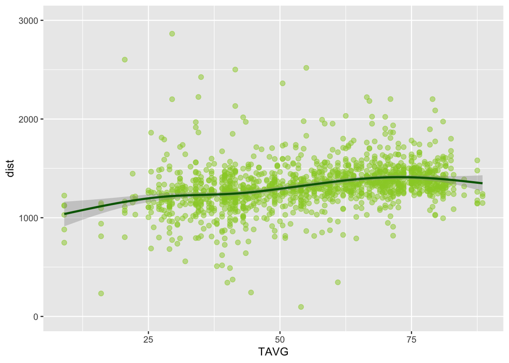

```r
ggplot(combined_gender, aes(x = TAVG, y = dist)) + geom_point(size = 2, alpha = 0.5, color = "yellowgreen") + geom_smooth(color = "darkgreen") + ylim(0,3000)
```

### How does the amount of precipitation affect the distance rode?

```r
str(combined_gender)
```

```
## 'data.frame':    1403 obs. of  14 variables:
##  $ day   : Date, format: "2019-01-01" "2019-01-01" ...
##  $ gender: Factor w/ 3 levels "female","male",..: 3 1 2 3 1 2 2 1 3 2 ...
##  $ dayid : Factor w/ 2 levels "Weekday","Weekend": 1 1 1 1 1 1 1 1 1 1 ...
##  $ count : int  27 49 137 20 75 232 306 70 14 58 ...
##  $ dist  : num  1344 1048 1335 958 1391 ...
##  $ dur   : num  1707 931 890 1207 809 ...
##  $ speed : num  0.787 1.126 1.5 0.794 1.719 ...
##  $ AWND  : num  NA NA NA NA NA NA NA NA NA NA ...
##  $ PRCP  : num  0.06 0.06 0.06 0 0 0 0 0 0 0 ...
##  $ SNOW  : num  0 0 0 0 0 0 0 0 0 0 ...
##  $ SNWD  : num  0 0 0 0 0 0 0 0 0 0 ...
##  $ TAVG  : num  48.5 48.5 48.5 37.5 37.5 37.5 40.5 40.5 40.5 41 ...
##  $ TMAX  : int  58 58 58 40 40 40 44 44 44 47 ...
##  $ TMIN  : int  39 39 39 35 35 35 37 37 37 35 ...
```

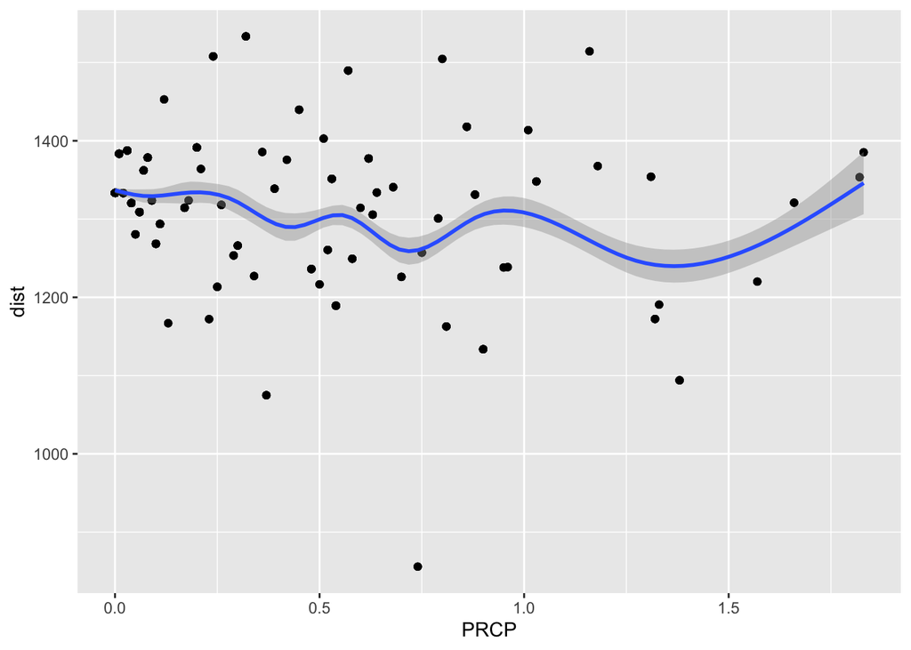

```r
combined_gender %>%
  group_by(PRCP) %>%
  summarize(count = n(),
            dist = mean(dist, na.rm = TRUE),
            avgprcp = mean(PRCP, na.rm = TRUE),
            speed = dist/dur) %>%
  ggplot(aes(x = PRCP,y = dist)) + geom_point() + geom_smooth()
```

### Relationship between average temperature and distance

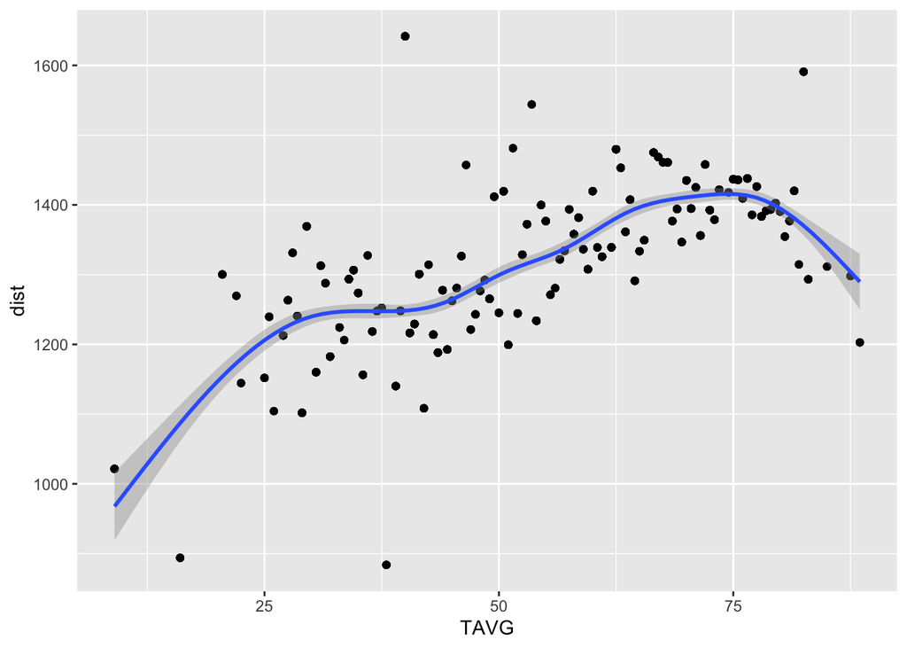

```r
combined_gender %>%
  group_by(TAVG) %>%
  summarize(count = n(),
            dist = mean(dist, na.rm = TRUE),
            avgprcp = mean(PRCP, na.rm = TRUE),
            speed = dist/dur) %>%
  ggplot(aes(x = TAVG,y = dist)) + geom_point() + geom_smooth()
```

This graph shows the average distance ridden for each recorded temperature. The ridership tends to ride a longer distance in higher temperatures, with a pretty clear positive correlation shown by the trend line. Citi gets a larger ridership in the summer, so they need to stock more bikes at different stations to reduce individual bike usage and maintainence costs.

### Does the ridership distance differ between months?

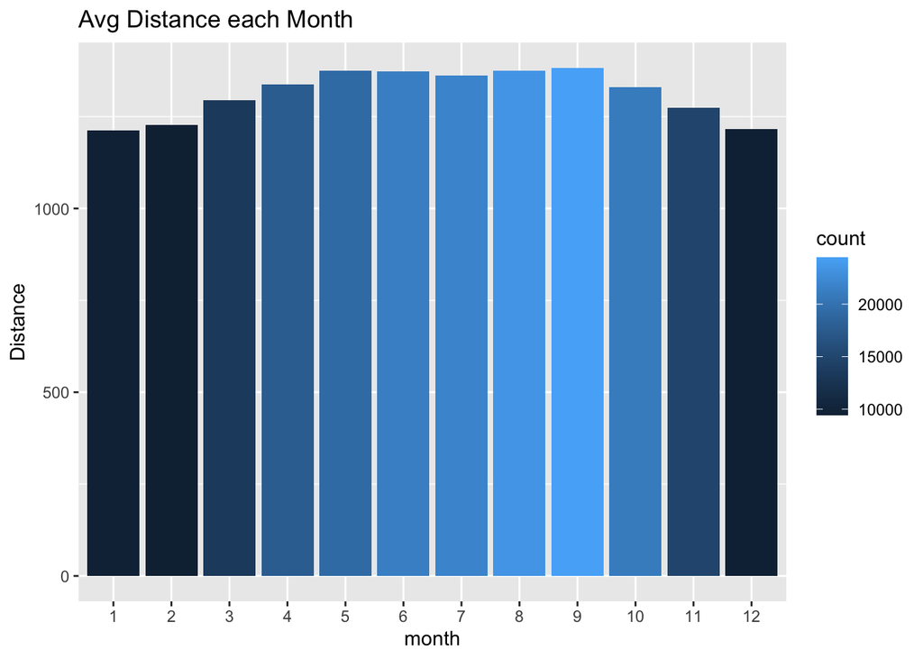

```r
citisample %>%
  group_by(month) %>%
  summarize(count = n(),
            dist = mean(distmeters, na.rm = TRUE),
            dur = mean(tripduration, na.rm = TRUE),
            speed = dist/dur) %>%
  ggplot(aes(x=month, y = dist, fill = count)) + geom_col() +labs(y="Distance", title = "Avg Distance each Month" )
```

This graph shows how the average distance of riders differs by month. This is similar to the previous graph, in that riders tend to ride for a longer distance in the summer months, which are warmer, and shorter in the colder months. Again, this creates the issue that Citibike needs to consider reducing bike supply in the winter months and increasing bike supply in the summer months, as more distance creates more wear and tear so more bikes would be optimal to ensure there are enough bikes to satisfy demand.